# Project 5: Explore and Summarize Data

**Understanding the data**

```
## 'data.frame':    1000 obs. of  8 variables:
##  $ gender                     : Factor w/ 2 levels "female","male": 1 1 1 2 2 1 1 2 2 1 ...
##  $ race.ethnicity             : Factor w/ 5 levels "group A","group B",..: 2 3 2 1 3 2 2 2 4 2 ...
##  $ parental.level.of.education: Factor w/ 6 levels "associate's degree",..: 2 5 4 1 5 1 5 5 3 3 ...
##  $ lunch                      : Factor w/ 2 levels "free/reduced",..: 2 2 2 1 2 2 2 1 1 1 ...
##  $ test.preparation.course    : Factor w/ 2 levels "completed","none": 2 1 2 2 2 2 1 2 1 2 ...
##  $ math.score                 : int  72 69 90 47 76 71 88 40 64 38 ...
##  $ reading.score              : int  72 90 95 57 78 83 95 43 64 60 ...
##  $ writing.score              : int  74 88 93 44 75 78 92 39 67 50 ...
```

|  | gender | race.ethnicity | parental.level.of.education | lunch | test.preparation.course | math.score | reading.score | writing.score |
| --- | --- | --- | --- | --- | --- | --- | --- | --- |
| 1 | female | group B | bachelor's degree | standard | none | 72 | 72 | 74 |
| 2 | female | group C | some college | standard | completed | 69 | 90 | 88 |
| 3 | female | group B | master's degree | standard | none | 90 | 95 | 93 |
| 4 | male | group A | associate's degree | free/reduced | none | 47 | 57 | 44 |
| 5 | male | group C | some college | standard | none | 76 | 78 | 75 |
| 6 | female | group B | associate's degree | standard | none | 71 | 83 | 78 |

```
##
## female   male
##    518    482
```

```
##
## group A group B group C group D group E
##      89     190     319     262     140
```

```
##
## associate's degree  bachelor's degree        high school
##                222                118                196
##    master's degree       some college   some high school
##                 59                226                179
```

```
##
## free/reduced     standard
##          355          645
```

```
##
## completed      none
##       358       642
```

```
##
## associate's degree  bachelor's degree        high school
##                222                118                196
##    master's degree       some college   some high school
##                 59                226                179
```

**Exploratory data analysis**

*1. Students By Gender*

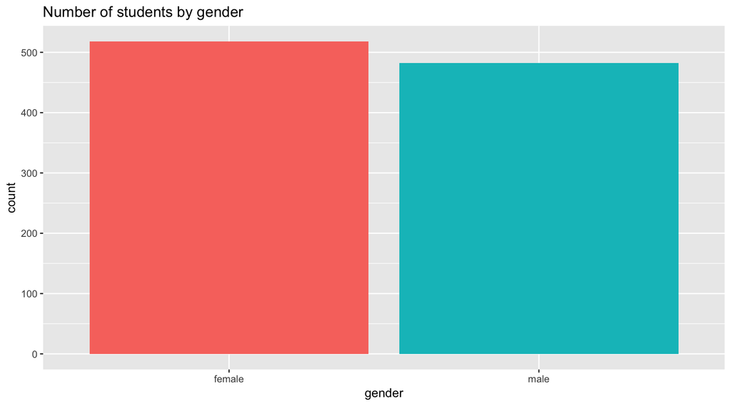

*2. Students By Race*

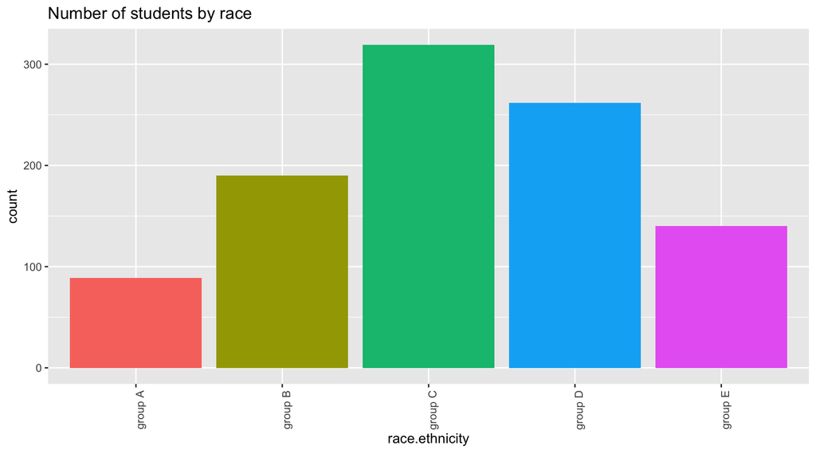

*3. Students By Parental level of education*

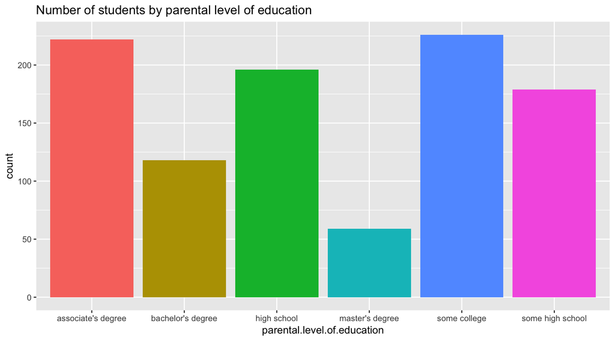

**Scores by Gender**

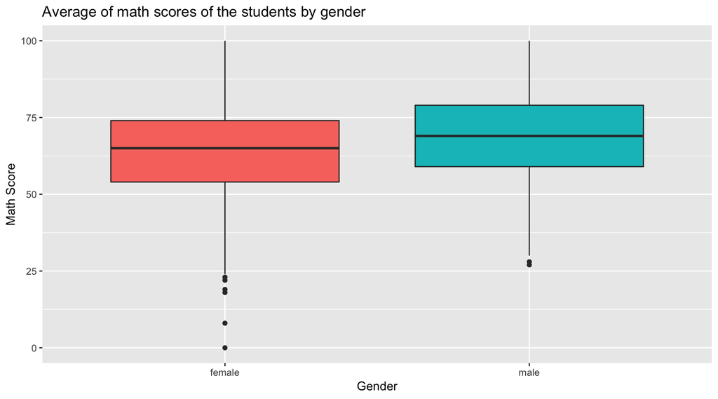

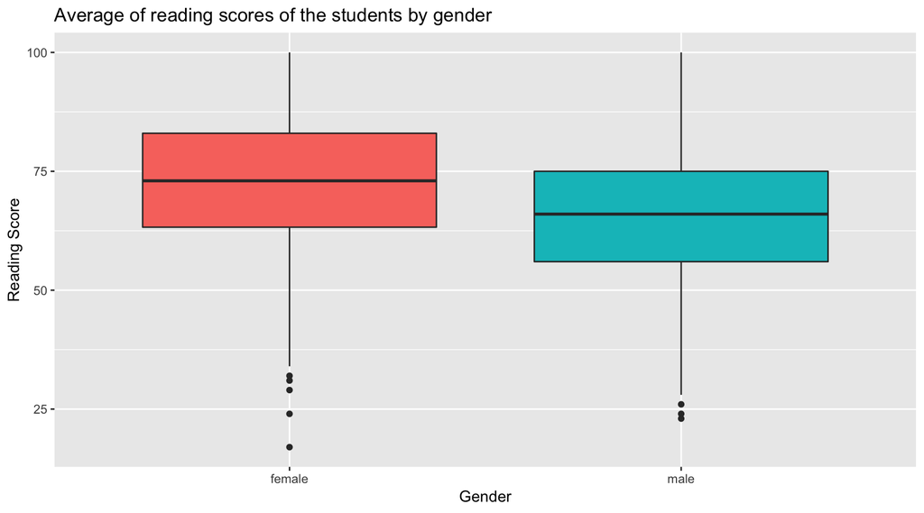

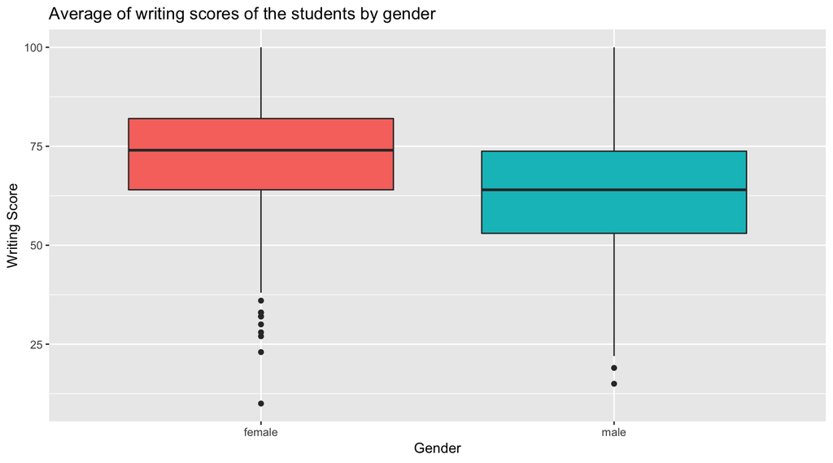

**Scores by Race**

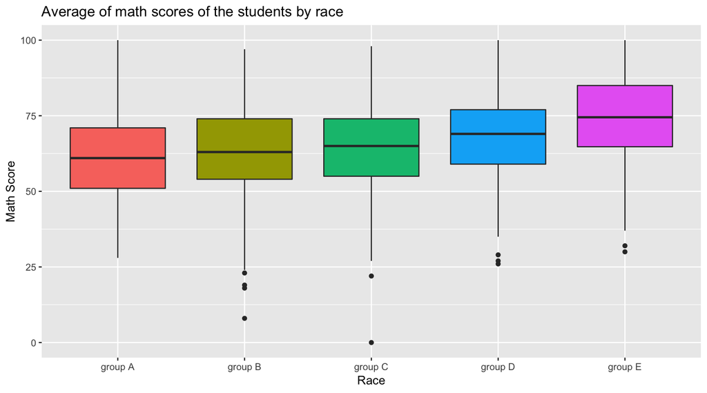

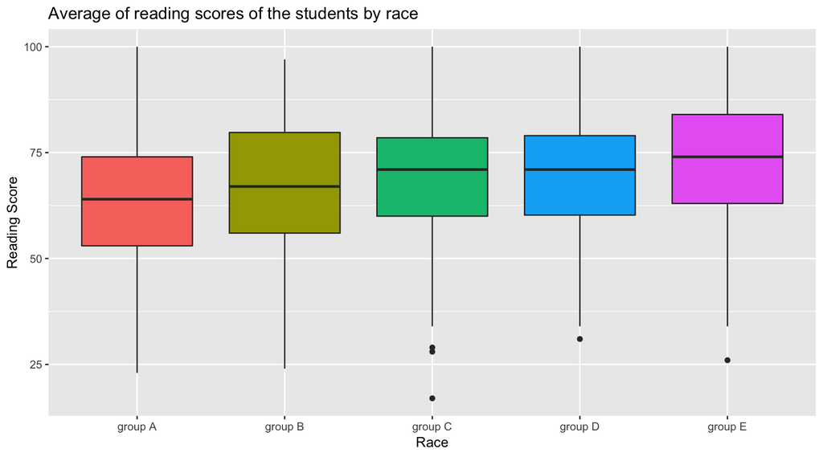

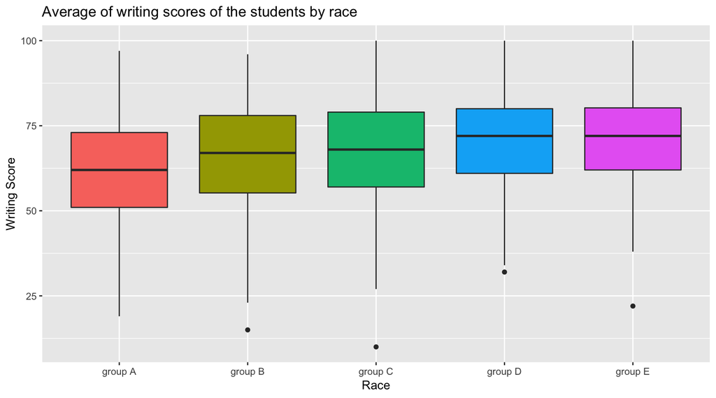

**Scores by Parental level of education**

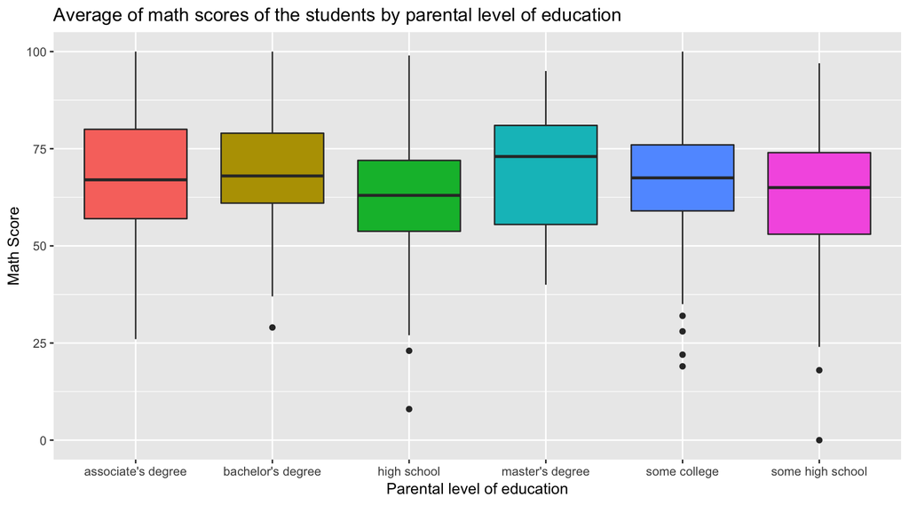

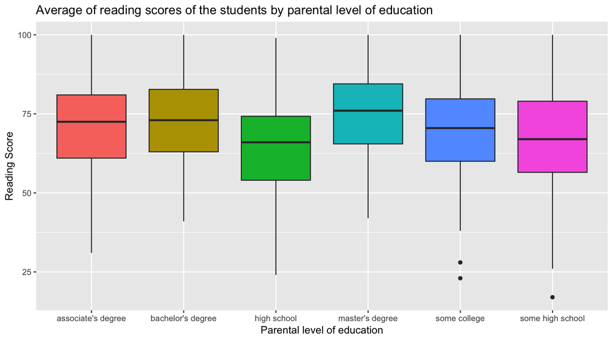

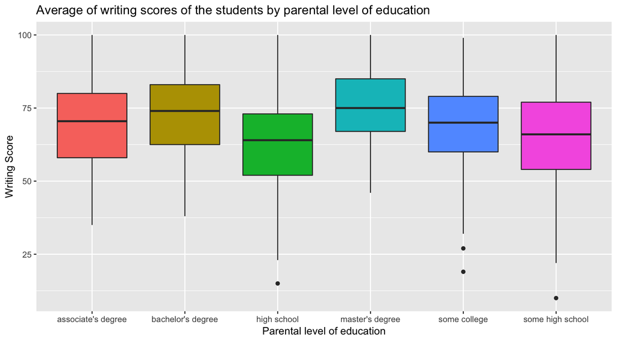

**Correlation between courses scores**

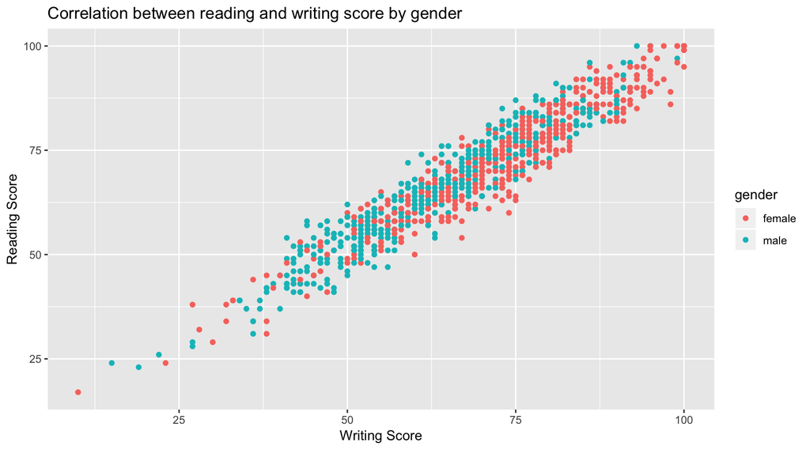

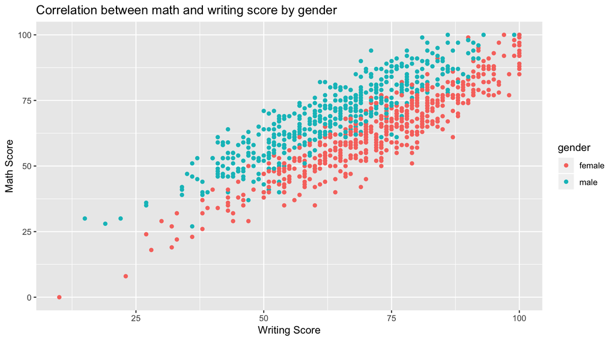

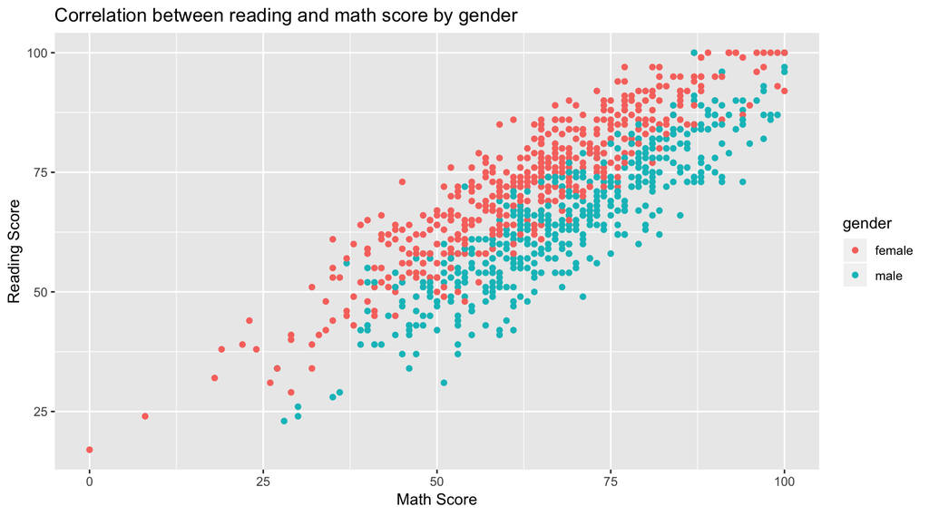

**Add columns for grade marks for each exam**

The code to add a column to a data frame with nested IFELSE [Code reference](https://stackoverflow.com/questions/36919001/nested-ifelse-in-adding-a-column-to-a-data-frame)

|  | gender | race.ethnicity | parental.level.of.education | lunch | test.preparation.course | math.score | reading.score | writing.score | math.grade | writing.grade | reading.grade |
| --- | --- | --- | --- | --- | --- | --- | --- | --- | --- | --- | --- |
| 1 | female | group B | bachelor's degree | standard | none | 72 | 72 | 74 | C | C | C |
| 2 | female | group C | some college | standard | completed | 69 | 90 | 88 | D | B | A |
| 3 | female | group B | master's degree | standard | none | 90 | 95 | 93 | A | A | A |
| 4 | male | group A | associate's degree | free/reduced | none | 47 | 57 | 44 | F | F | E |
| 5 | male | group C | some college | standard | none | 76 | 78 | 75 | C | C | C |
| 6 | female | group B | associate's degree | standard | none | 71 | 83 | 78 | C | C | B |

*Students grade By courses and gender*

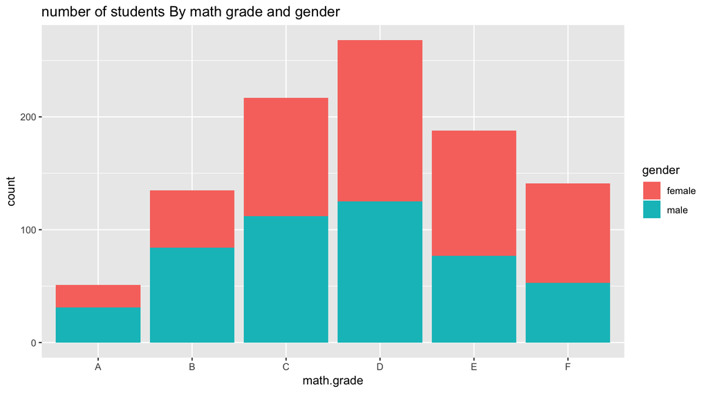

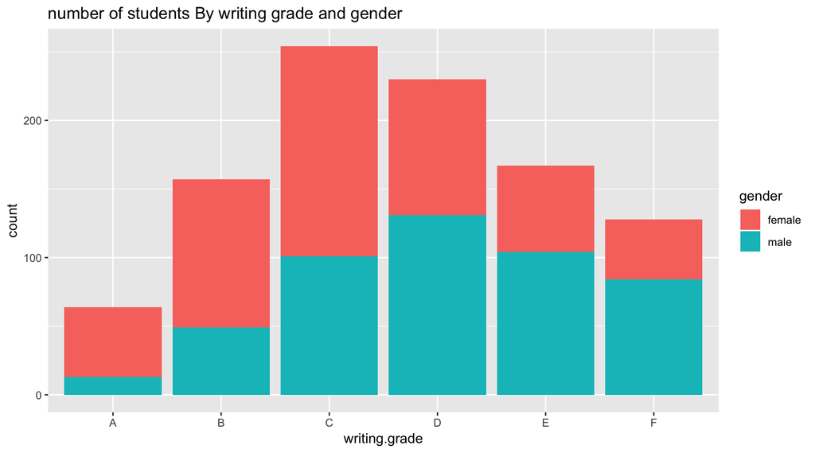

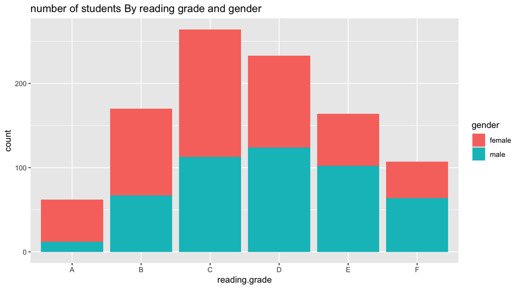

**Scores by Preparation course**

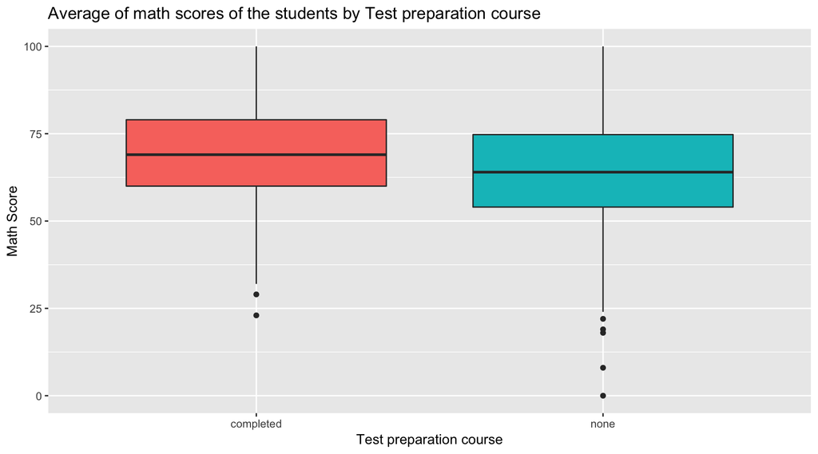

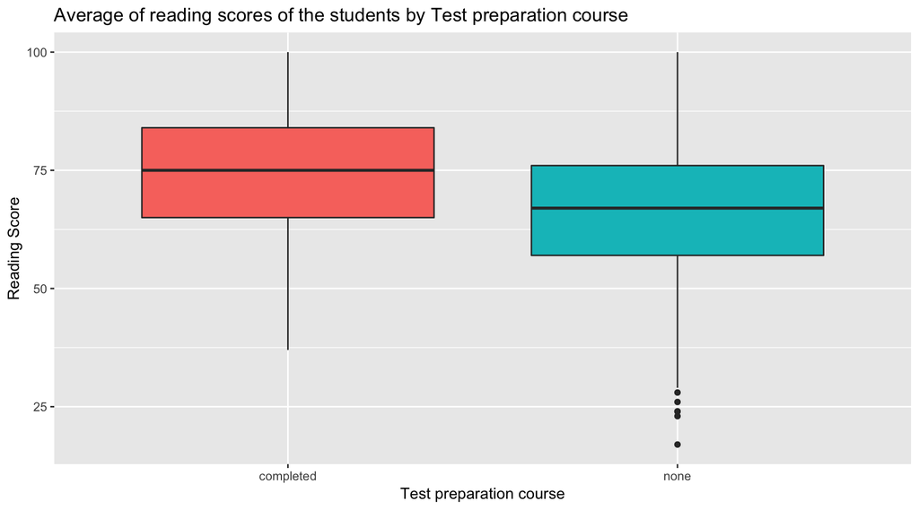

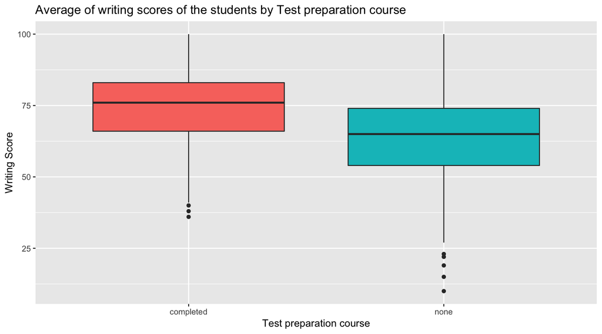

## Final Plots and Summary

### Plot One

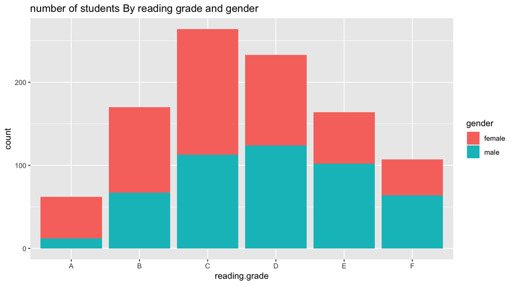

### Plot Two

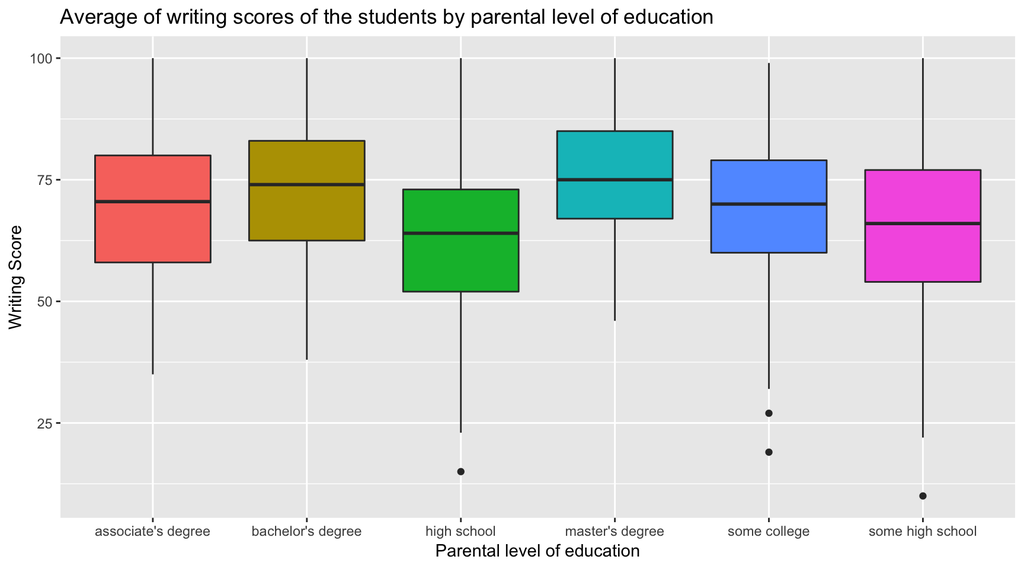

## Plot Three

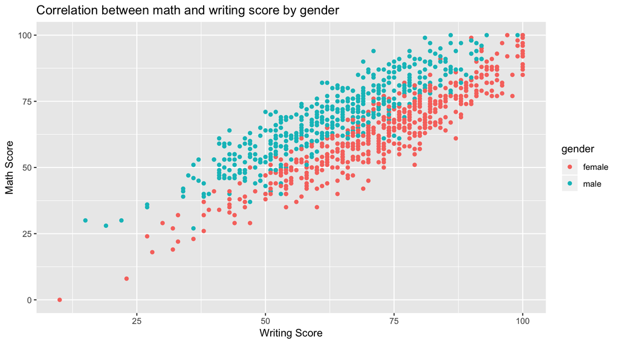

### Description Three

The scatter plot shows that there is a Positive correlation between math and writing score. Also shows that Males having a better math score than Females. On the other hand Females having a better writing score than Males

## Reflection

The Students Performance in Exams data set contains information on almost 1000 students across 11 variables. I started by understanding the individual variables in the data set, and then I explored interesting questions and leads as I continued to make observations on plots. I explored the students scores across many variables.

There was a clear trend between the Test preparation course and the average of student scores.the limitations of my model was that the data dosen’t have more students grades. To investigate this data further, I would investigate students scores for each race with gender, and see which gender in which race are the student are likely have a grater score than other races.